# Routinely Randomize Potential Sources of Measurement Reactivity to Estimate and Adjust for Biases in Subjective Reports

```r
options(stringsAsFactors = FALSE)
#' show two significant digits tops
options(digits = 2)
#' tend not to show scientific notation, because we're just psychologists
options(scipen = 7)
#' make output a bit wider
options(width = 110)
#' set a seed to make analyses depending on random number generation reproducible
set.seed(1710) # if you use your significant other's birthday make sure you stay together for the sake of reproducibility


#' ## Load packages
#' generate the site
library(rmarkdown)
#' set options for chunks
library(knitr)
#' my formr utility package to generate e.g. the bibliography
library(formr)
#' pretty-printed output
library(pander)
#' tidyverse date times
library(lubridate)
#' tidyverse strings
library(stringr)
#' extractor functions for models
library(broom)
#' grammar of graphics plots
library(ggplot2)
#' svg graphs
# library(svglite);
library(feather)
library(ggthemes)
library(codebook)
library(kableExtra)
library(Cairo)
library(paletteer)

#' tidyverse: has a lot of naming conflicts, so always load last
library(tidyverse)
opts_chunk$set(warning = F, message = F, error = TRUE, fig.width = 15, fig.height = 6)
library(broom.mixed)
library(tidylog)
options(width = 4000)
theme_set(theme_classic() + theme_pander(base_size = 18))
```

```r
key <- keyring::key_get_raw("encrypt_data_routinely_randomise")
class(key) <- c("aes", "raw")
key <- cyphr::key_openssl(key)
s3_daily_id_answered <- cyphr::decrypt(readRDS("s3_daily_id_answered.rds"), key)
diary <- cyphr::decrypt(readRDS("diary.rds"), key)

# s3_daily_id_answered <-  rio::import("../routine_and_sex/data/s3_daily_id_answered.feather")

first_page = s3_daily_id_answered  %>%
  filter(item_name %in% c("irritable", "self_esteem", "risk_taking", "good_mood", "loneliness", "relationship_satisfaction", "stressed")) %>%
  group_by(session, unit_session_id) %>%
  mutate(display_order = min_rank(display_order),
         number_of_items_shown = n()) %>%
  arrange(session, unit_session_id, display_order) %>%
  mutate(
        last_item = if_na(lag(label_english), "[None]")) %>%
  ungroup() %>%
  mutate(last_item = relevel(factor(last_item), ref =  "[None]")) %>%
  filter(item_name %in% c("irritable", "self_esteem", "risk_taking", "good_mood", "loneliness", "stressed"))
```

# 1 Description

The following items were shown in random order on the first page of our diary.

- I was stressed. (40% probability of being shown)
- I was lonely. (40%)
- My mood was good. (80%)
- I was prepared to take risks. (20%)
- I was satisfied with myself. (80%)
- I was irritable. (40%)

Participants (n=1345 women) could answer on a 5 point likert scale from “less than usual” [0] to “more than usual” [4]. Pole labels were placed left and right of blank, equally sized buttons. Participants answered the diary on 60982 days in total, or on 45 days per woman. Because of our planned missing design with randomised display and order, participants saw only a subset of these items each day. Therefore, the following were randomised variables - the day an item was first shown (conditional on adjusting for day number), - the number of times an item was seen previously (conditional as above). - the number of items on that day. - the display order.

## 1.1 Table 1

```r
first_page %>% mutate(days_tot = n_distinct(unit_session_id)) %>% group_by(label_english) %>%
  summarise(women = n_distinct(session),
            days = n_distinct(unit_session_id),
            per_woman = round(days/women),
            mean = sprintf("%.2f", mean(answer, na.rm = T)),
            sd = sprintf("%.2f", sd(answer, na.rm = T)),
  pct_shown = round(days/first(days_tot),1)) %>%
  kable()
```

| label_english | women | days | per_woman | mean | sd | pct_shown |
| --- | --- | --- | --- | --- | --- | --- |
| I felt lonely. | 1305 | 24520 | 19 | 1.40 | 1.14 | 0.4 |
| I was easily irritated. | 1298 | 24681 | 19 | 1.61 | 1.12 | 0.4 |
| I was prepared to take risks. | 1268 | 12229 | 10 | 1.80 | 0.95 | 0.2 |
| I was satisfied with myself. | 1337 | 49213 | 37 | 2.11 | 0.97 | 0.8 |
| I was stressed out. | 1313 | 24574 | 19 | 1.82 | 1.18 | 0.4 |
| My mood was good. | 1338 | 49224 | 37 | 2.19 | 1.03 | 0.8 |

## 1.2 Table 2

```r
first_page %>%
  mutate(first_day_of_item = if_else(first_day_of_item > 6, "7+", as.character(first_day_of_item))) %>%
  group_by(label_english) %>%
  mutate(n_subjects = n_distinct(session)) %>%
  group_by(label_english, first_day_of_item) %>%
  summarise(n = paste0(n_distinct(session), " (", round(n_distinct(session)/first(n_subjects) * 100), "%)")) %>%
  spread(first_day_of_item, n, fill = 0) %>%
  rename(Item = label_english) %>%
  kable(caption = "Number of women who first saw each item on the first, second, ..., n-th day.") %>%
  add_header_above(c(" " = 1, "First day of item presentation" = 8))
```

Number of women who first saw each item on the first, second, …, n-th day.

| Item | First day of item presentation 0 | First day of item presentation 1 | First day of item presentation 2 | First day of item presentation 3 | First day of item presentation 4 | First day of item presentation 5 | First day of item presentation 6 | First day of item presentation 7+ |
| --- | --- | --- | --- | --- | --- | --- | --- | --- |
| I felt lonely. | 575 (44%) | 278 (21%) | 160 (12%) | 110 (8%) | 66 (5%) | 38 (3%) | 22 (2%) | 56 (4%) |
| I was easily irritated. | 513 (40%) | 281 (22%) | 168 (13%) | 107 (8%) | 79 (6%) | 48 (4%) | 33 (3%) | 69 (5%) |
| I was prepared to take risks. | 251 (20%) | 176 (14%) | 165 (13%) | 109 (9%) | 101 (8%) | 69 (5%) | 68 (5%) | 329 (26%) |
| I was satisfied with myself. | 1078 (81%) | 190 (14%) | 43 (3%) | 14 (1%) | 4 (0%) | 3 (0%) | 1 (0%) | 4 (0%) |
| I was stressed out. | 530 (40%) | 275 (21%) | 159 (12%) | 112 (9%) | 73 (6%) | 63 (5%) | 39 (3%) | 62 (5%) |
| My mood was good. | 1078 (81%) | 177 (13%) | 52 (4%) | 19 (1%) | 3 (0%) | 6 (0%) | 0 | 3 (0%) |

## 1.3 Information for the narrative description of the study.

```r
diary <- s3_daily_id_answered %>%
  ungroup() %>%
  select(session, day_number) %>%
  distinct() %>%
  left_join(diary)

skimr::skim_with(haven_labelled = skimr::get_skimmers()$numeric)
all_surveys <- diary %>% ungroup() %>%
  select(session, didntmissfirstweek, hetero_relationship,
                          age, education_years, has_children, nr_children, relationship_status,
                          occupational_status) %>%
  distinct()
diary %>% filter(did_not_finish_entry == 0) %>% nrow()
```

```
## [1] 60959
```

```r
first_page %>% group_by(session, unit_session_id) %>%
  summarise(answered = any(!is.na(answer))) %>%
  summarise(days = sum(answered)) %>%
  select(days) %>%
  skimr::skim_to_wide() %>%
  kable()
```

| type | variable | missing | complete | n | mean | sd | p0 | p25 | p50 | p75 | p100 | hist |
| --- | --- | --- | --- | --- | --- | --- | --- | --- | --- | --- | --- | --- |
| integer | days | 0 | 1345 | 1345 | 45.41 | 22.34 | 1 | 26 | 54 | 65 | 70 | ▂▂▂▁▂▂▃▇ |

```r
all_surveys %>%
  haven::zap_labels() %>%
  select(age, hetero_relationship, education_years, has_children, nr_children) %>% skimr::skim_to_wide() %>%
  kable()
```

| type | variable | missing | complete | n | mean | sd | p0 | p25 | p50 | p75 | p100 | hist |
| --- | --- | --- | --- | --- | --- | --- | --- | --- | --- | --- | --- | --- |
| numeric | age | 0 | 1345 | 1345 | 26.46 | 7.19 | 18 | 22 | 25 | 29 | 61 | ▇▇▃▁▁▁▁▁ |
| numeric | education_years | 0 | 1345 | 1345 | 15.12 | 4.82 | 0 | 13 | 16 | 18 | 26 | ▁▁▁▅▇▇▂▁ |
| numeric | has_children | 0 | 1345 | 1345 | 0.11 | 0.32 | 0 | 0 | 0 | 0 | 1 | ▇▁▁▁▁▁▁▁ |
| numeric | hetero_relationship | 0 | 1345 | 1345 | 0.67 | 0.47 | 0 | 0 | 1 | 1 | 1 | ▃▁▁▁▁▁▁▇ |
| numeric | nr_children | 1194 | 151 | 1345 | 1.7 | 0.77 | 1 | 1 | 2 | 2 | 5 | ▇▇▁▂▁▁▁▁ |

```r
occupational_status <- all_surveys$occupational_status
sort(round(props(occupational_status),2)) %>%
  kable()
```

| occupational_status | Freq |
| --- | --- |
| employed, intern | 0.00 |
| homemaker, employed | 0.00 |
| intern | 0.00 |
| not_working, employed | 0.00 |
| not_working, homemaker | 0.00 |
| not_working, intern | 0.00 |
| not_working, student | 0.00 |
| pupil, student | 0.00 |
| student, employed, intern | 0.00 |
| student, homemaker | 0.00 |
| student, homemaker, employed | 0.00 |
| trainee, employed | 0.00 |
| trainee, homemaker, employed | 0.00 |
| trainee, student | 0.00 |
| homemaker | 0.01 |
| pupil | 0.01 |
| student, intern | 0.01 |
| not_working | 0.02 |
| trainee | 0.02 |
| student, employed | 0.03 |
| employed | 0.25 |
| student | 0.62 |

```r
sort(round(props(occupational_status %contains% "student"),2))
```

```
## occupational_status %contains% "student"
## FALSE  TRUE
##  0.33  0.67
```

```r
sort(round(props(occupational_status %contains% "employed"),2))
```

```
## occupational_status %contains% "employed"
##  TRUE FALSE
##   0.3   0.7
```

```r
relationship_status <- all_surveys$relationship_status
sort(round(props(haven::as_factor(relationship_status)),2))
```

```
## haven::as_factor(relationship_status)
##               other             engaged  loose relationship             married              Single steady relationship
##                0.01                0.02                0.06                0.09                0.32                0.49
```

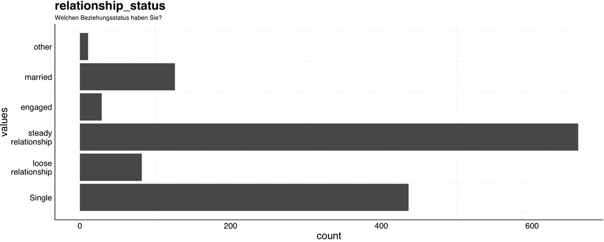

```r
codebook::plot_labelled(relationship_status) + coord_flip()
```

# 2 Bias tests

## 2.1 Figure 1: Reaction times

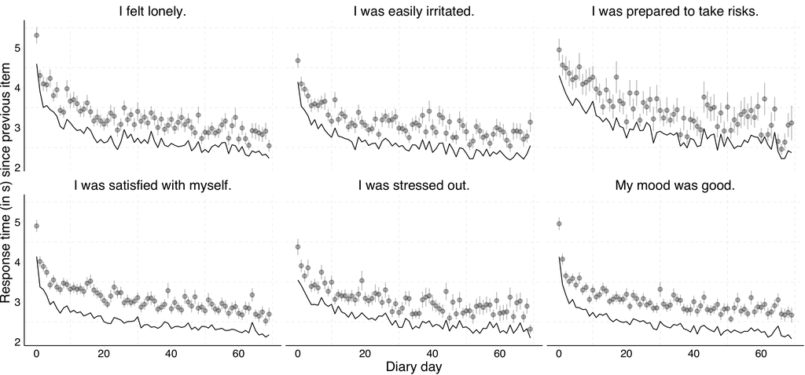

```r
first_page %>% filter(response_time_since_previous < 1*30*1000, response_time_since_previous > 0, display_order > 1) %>%
  ggplot(., aes(day_number, response_time_since_previous/1000)) +
  geom_pointrange(alpha = 0.3, position = position_dodge(width = 0.2), stat ='summary', fun.data = 'mean_se') +
  geom_line(position = position_dodge(width = 0.4), stat = 'summary', fun.y = function(x) { mean(x, na.rm =T, trim = 0.10) }) +
  scale_y_continuous("Response time (in s) since previous item") +
  scale_x_continuous("Diary day") +
  facet_wrap(~ label_english)
```

```r
ggsave(width = opts_current$get("fig.width"), height = opts_current$get("fig.height"), filename = "Figure1.png", res = 600)
```

```
## Error in grDevices::png(..., res = dpi, units = "in"): formal argument "res" matched by multiple actual arguments
```

```r
ggsave(width = opts_current$get("fig.width"), height = opts_current$get("fig.height"), filename = "Figure1.tiff", compression = "jpeg", dpi = 600)
```

## 2.2 Figure 2: Initial elevation

In this graph, we show mean response to the item, depending on which day of the diary we first asked it. Different-coloured lines reflect different starting days. We only show lines based on at least twenty participants to reduce noise. Therefore, fewer lines are shown for items with a higher probability of being shown. Wherever the initial point of each line exceeds the mean of the other lines on the day, this would be evidence for initial elevation bias.

In this graph, we show the first week. The Y axes include the global mean ± 1 global standard deviation for each item.

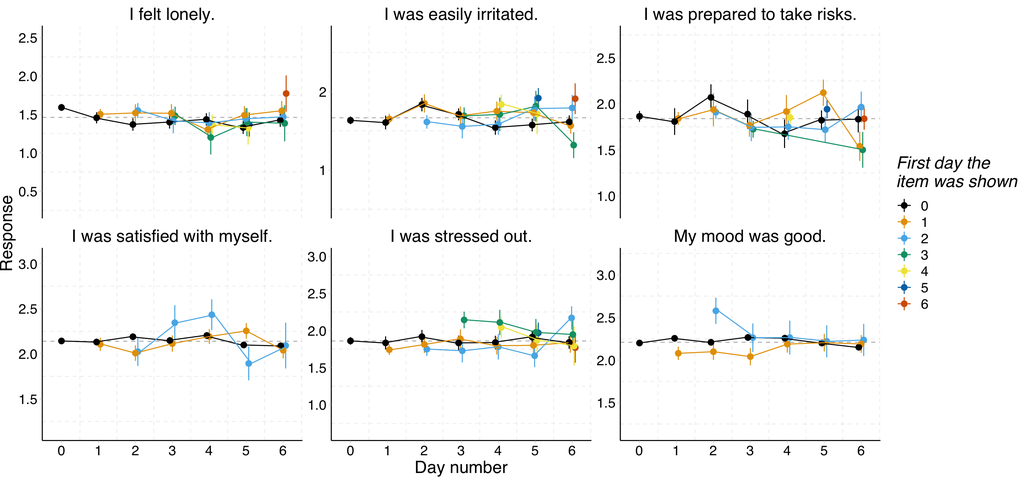

```r
first_page %>%
  filter(day_number < 7) %>%
  group_by(item_name) %>%
  mutate(group_mean = mean(answer, na.rm = TRUE)) %>%
  group_by(item_name, day_number, first_day_of_item_factor) %>%
  filter(n_nonmissing(answer) > 20) %>%
  ggplot(., aes(day_number, answer, colour = first_day_of_item_factor)) +
  geom_blank(aes(y = item_mean, ymin = item_mean - item_sd, ymax = item_mean + item_sd)) +
  geom_hline(aes(yintercept = group_mean, group = label), color = "gray", linetype = 'dashed') +
  geom_pointrange(position = position_dodge(width = 0.2), stat = 'summary', fun.data = 'mean_se') +
  geom_line(position = position_dodge(width = 0.4), stat = 'summary', fun.data = 'mean_se') +
  scale_color_colorblind("First day the\nitem was shown") +
  scale_y_continuous("Response") +
  facet_wrap(~ label_english, scales = "free_y", nrow = 2) +
  scale_x_continuous("Day number", breaks = 0:10)
```

```r
ggsave(width = opts_current$get("fig.width"), height = opts_current$get("fig.height"), filename = "Figure2.png", res = 600)
```

```
## Error in grDevices::png(..., res = dpi, units = "in"): formal argument "res" matched by multiple actual arguments
```

```r
ggsave(width = opts_current$get("fig.width"), height = opts_current$get("fig.height"), filename = "Figure2.tiff", compression = "jpeg", dpi = 600)
```

## 2.3 Figure 3: Item order

The item order on each page was randomised too. If the mechanism for initial elevation bias involves familiarity with the response scale, we might expect to find that the first item on the first page on the first day is answered differently than later responses. Different mechanisms of response bias (e.g., amount of mouse movement required to reply is equal for all responses for the first item, but reduced for unchanged responses to lower down items) could lead to different response biases according to item order.

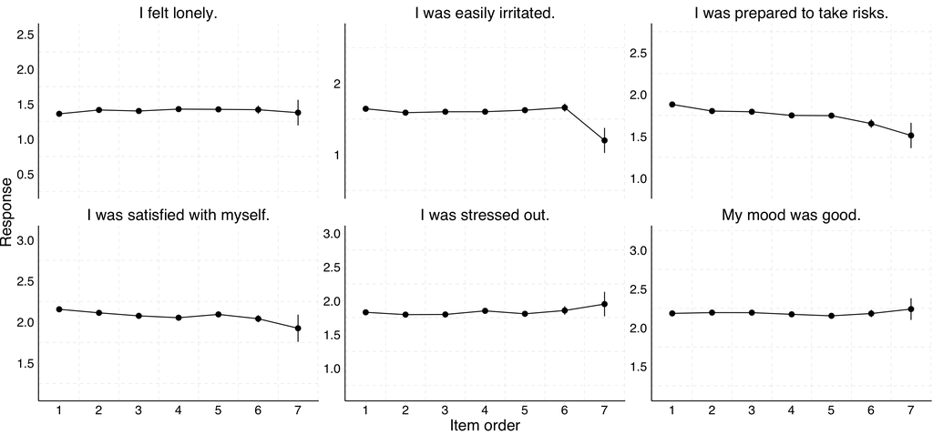

```r
first_page %>%
  ggplot(., aes(display_order, answer)) +
  geom_blank(aes(y = item_mean, ymin = item_mean - item_sd, ymax = item_mean + item_sd)) +
  # geom_smooth(aes(group = session), method = 'lm', color = "#00000011", se = FALSE) +
  geom_pointrange(position = position_dodge(width = 0.2), stat = 'summary', fun.data = 'mean_se') +
  geom_line(position = position_dodge(width = 0.4), stat = 'summary', fun.data = 'mean_se') +
  scale_y_continuous("Response") +
  scale_x_continuous("Item order", breaks = 1:7) +
  facet_wrap(~ label_english, scales = 'free_y')
```

```r
ggsave(width = opts_current$get("fig.width"), height = opts_current$get("fig.height"), filename = "Figure3.png", res = 600)
```

```
## Error in grDevices::png(..., res = dpi, units = "in"): formal argument "res" matched by multiple actual arguments
```

```r
ggsave(width = opts_current$get("fig.width"), height = opts_current$get("fig.height"), filename = "Figure3.tiff", compression = "jpeg", dpi = 600)
```

## 2.4 Figure 4: Last item identity

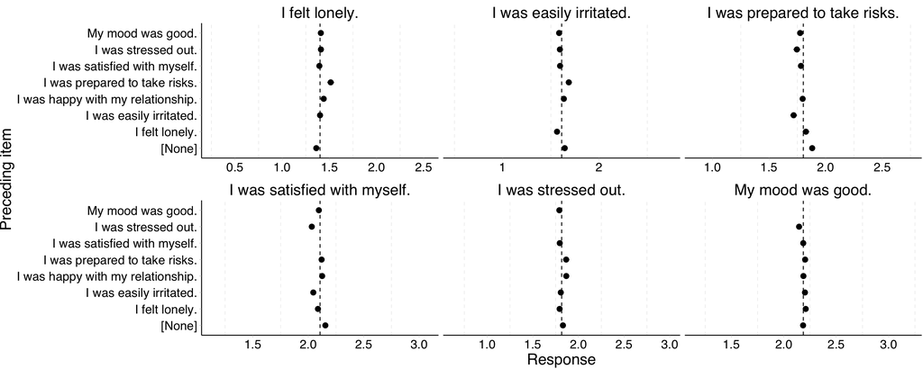

```r
first_page %>%
  ggplot(., aes(last_item, answer)) +
  geom_blank(aes(y = item_mean, ymin = item_mean - item_sd, ymax = item_mean + item_sd)) +
  geom_hline(aes(yintercept = item_mean), linetype = 'dashed') +
  geom_pointrange(position = position_dodge(width = 0.2), stat ='summary', fun.data = 'mean_se') +
  # geom_line(position = position_dodge(width = 0.4), stat ='summary', fun.data = 'median_hilow') +
  scale_y_continuous("Response") +
  scale_x_discrete("Preceding item") +
  coord_flip() +
  facet_wrap(~ label_english, scales = 'free_x')
```

```r
ggsave(width = opts_current$get("fig.width"), height = opts_current$get("fig.height"), filename = "Figure4.png", res = 600)
```

```
## Error in grDevices::png(..., res = dpi, units = "in"): formal argument "res" matched by multiple actual arguments
```

```r
ggsave(width = opts_current$get("fig.width"), height = opts_current$get("fig.height"), filename = "Figure4.tiff", compression = "jpeg", dpi = 600)
```

## 2.5 Figure 5: Number of items shown

As mentioned above, the number of items shown is also a randomised variable. It is in turn confounded with item order, because items shown on a page with more items are likely to have a later item order. Most importantly, when only one item is shown, item order is also one. As above, we can not only examine the mean but also the relative frequencies of each response.

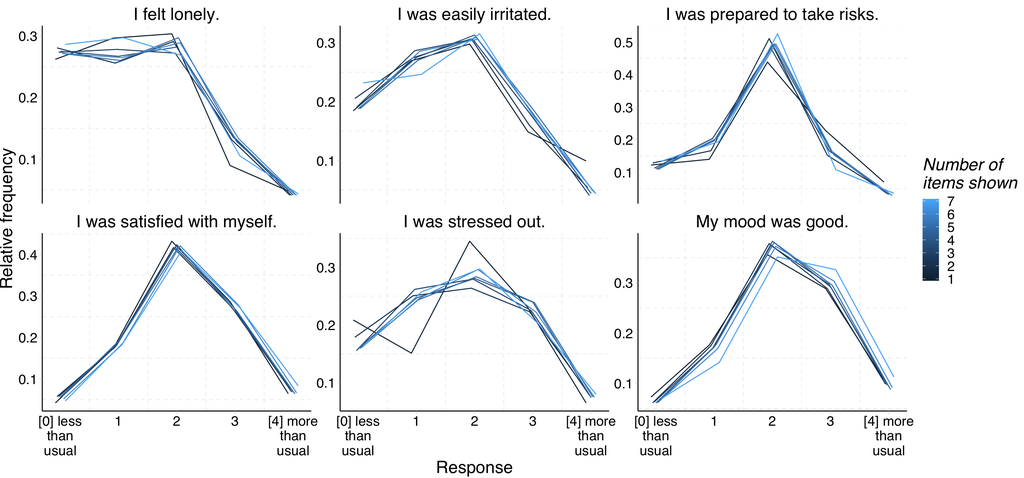

```r
first_page %>%
  group_by(label_english, item_name, number_of_items_shown) %>%
  mutate(group_n = n_nonmissing(answer)) %>%
  group_by(label_english, item_name, number_of_items_shown, answer) %>%
  summarise(rel_freq = n_nonmissing(answer)/first(group_n)) %>%
  ggplot(., aes(answer, y = rel_freq, colour = number_of_items_shown, group = number_of_items_shown)) +
  geom_line(position = position_dodge(width = 0.2)) +
  scale_color_continuous("Number of\nitems shown") +
  scale_y_continuous("Relative frequency") +
  scale_x_continuous("Response", breaks = 0:4, labels = c("[0] less\nthan\nusual", 1, 2, 3, "[4] more\nthan\nusual")) +
  facet_wrap(~ label_english, scales = "free_y")
```

```r
ggsave(width = opts_current$get("fig.width"), height = opts_current$get("fig.height"), filename = "Figure5.png", res = 600)
```

```
## Error in grDevices::png(..., res = dpi, units = "in"): formal argument "res" matched by multiple actual arguments
```

```r
ggsave(width = opts_current$get("fig.width"), height = opts_current$get("fig.height"), filename = "Figure5.tiff", compression = "jpeg", dpi = 600)
```

## 2.6 Figure 6: Multilevel model responses

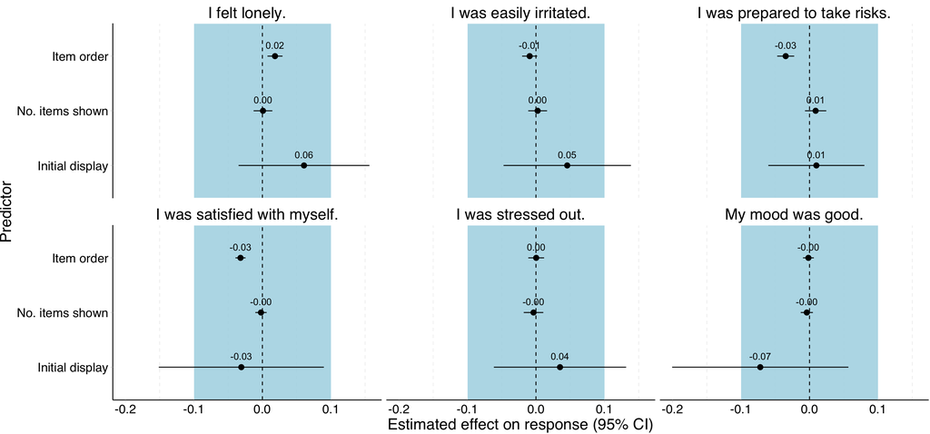

```r
predictors <- first_page %>%
  mutate(item_order = display_order,
         times_item_shown = times_item_answered,
         items_shown = number_of_items_shown
         )
library(lme4)
library(lmerTest)
library(broom.mixed)

complex_mods <-  predictors %>%
  split(.$item_name) %>%
  map(~ lmer(answer ~ weekday + items_shown + item_order + first_day_of_item_shown + day_number_factor + refer_time_period +  (1 | session), data = .))

all_biases <- complex_mods %>%
  map(~ tidy(., conf.int = TRUE, conf.level = 0.95)) %>%
  bind_rows(.id = "response")


all_biases %>%
  filter(is.na(group)) %>%
  filter(term != "(Intercept)") %>%
  left_join(
    first_page %>% select(response = item_name, item = label_english, item_mean, item_sd) %>% distinct()
  ) %>%
  mutate(term = fct_relevel(fct_recode(str_replace(term, "weekday", ""),
                           "No. times item shown" = "times_item_shown",
                           "Ref: since last entry" = "refer_time_periodlast entry",
                           "No. items shown" = "items_shown",
                           "Item order" = "item_order",
                           "Initial display" = "first_day_of_item_shownTRUE",
                           "Day" = "poly(scale(day_number, scale = F)/10, degree = 3, raw = T)1",
                           "Day^2" = "poly(scale(day_number, scale = F)/10, degree = 3, raw = T)2",
                           "Day^3" = "poly(scale(day_number, scale = F)/10, degree = 3, raw = T)3"),
                           "Initial display" ,
                           "No. items shown",
                           "No. times item shown",
                           "Item order",
                           "Ref: since last entry",
                           "Sunday","Saturday",  "Friday", "Thursday","Wednesday",  "Tuesday",
                           "Day^3",
                           "Day^2",
                           "Day")
                           ) %>%
  filter(term %in% c("Initial display" ,
                           "No. items shown",
                           "No. times item shown",
                           "Item order")) %>%
  # filter(term != "refer_time_periodlast entry",
         # str_sub(term, 1, 10) != "day_number", term != "(Intercept)", !is.na(conf.high)) %>%
  ggplot(aes(x = term, y = estimate, ymin = conf.low, ymax = conf.high)) +
  geom_rect(ymin = -0.1, ymax = 0.1, xmin = -Inf, xmax = Inf, fill = "lightblue", alpha = 0.5) +
  # geom_blank(aes(y = estimate, ymin = estimate - item_sd, ymax = estimate + item_sd)) +
  geom_hline(yintercept = 0, linetype = 'dashed') +
  ggrepel::geom_text_repel(aes(label = sprintf("%.2f",estimate)), force = 0, nudge_x = 0.2, segment.size = 0) +
  facet_wrap(~ item) +
  geom_pointrange() +
  scale_y_continuous("Estimated effect on response (95% CI)") +
  scale_x_discrete("Predictor") +
  coord_flip()
```

```r
ggsave(width = opts_current$get("fig.width"), height = opts_current$get("fig.height"), filename = "Figure6.png", res = 600)
```

```
## Error in grDevices::png(..., res = dpi, units = "in"): formal argument "res" matched by multiple actual arguments
```

```r
ggsave(width = opts_current$get("fig.width"), height = opts_current$get("fig.height"), filename = "Figure6.tiff", compression = "jpeg", dpi = 600)
```

## 2.7 Figure 7: Response time Multilevel models

Testing the times the item was seen already (reference category: first day) as a factor variable, rather than yes/no.

adjusting for day number (0 to 7+), the time period referred to (affected by how often people have responded so far), which day the item was first shown, the day number, and a random effect for the woman.

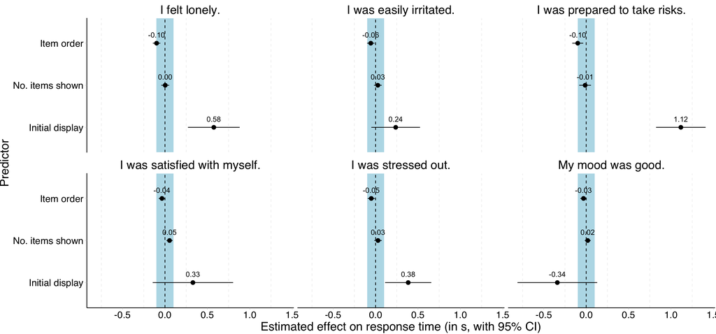

```r
predictors_rt <- predictors %>%
  filter(response_time_since_previous < 30*1000, response_time_since_previous > 0,
         item_order != "1")

library(lme4)
library(lmerTest)

complex_mods_rt <-  predictors_rt %>%
  split(.$item_name) %>%
  map(~ lmer(response_time_since_previous/1000 ~ weekday + items_shown + item_order + first_day_of_item_shown + day_number_factor + refer_time_period +  (1 | session), data = .))
# summary(lmer(response_time_since_previous/1000 ~ items_shown + item_order + times_item_shown + poly(scale(day_number, scale=F)/10, degree = 3, raw = T) + refer_time_period +  (1 | session), data = predictors %>% filter(item_name == 'good_mood')))
# qplot(predictors$response_time_since_previous/1000)

initial_elevation_bias_rt <- complex_mods_rt %>%
  map(~ tidy(., conf.int = TRUE, conf.level = 0.95)) %>%
  bind_rows(.id = "response")


initial_elevation_bias_rt %>%
  left_join(first_page %>% select(response = item_name, item = label_english) %>% distinct()) %>%
  filter(term != "(Intercept)", !is.na(conf.high)) %>%
  mutate(term = fct_relevel(fct_recode(str_replace(term, "weekday", ""),
                           "No. times item shown" = "times_item_shown",
                           "Ref: since last entry" = "refer_time_periodlast entry",
                           "No. items shown" = "items_shown",
                           "Item order" = "item_order",
                           "Initial display" = "first_day_of_item_shownTRUE",
                           "Day" = "poly(scale(day_number, scale = F)/10, degree = 3, raw = T)1",
                           "Day^2" = "poly(scale(day_number, scale = F)/10, degree = 3, raw = T)2",
                           "Day^3" = "poly(scale(day_number, scale = F)/10, degree = 3, raw = T)3"),
                           "Initial display" ,
                           "No. items shown",
                           "No. times item shown",
                           "Item order",
                           "Ref: since last entry",
                           "Sunday","Saturday",  "Friday", "Thursday","Wednesday",  "Tuesday",
                           "Day^3",
                           "Day^2",
                           "Day")
                           ) %>%
  filter(term %in% c("Initial display" ,
                           "No. items shown",
                           "No. times item shown",
                           "Item order")) %>%
  # filter(term != "refer_time_periodlast entry",
         # str_sub(term, 1, 10) != "day_number", term != "(Intercept)", !is.na(conf.high)) %>%
  ggplot(aes(x = term, y = estimate, ymin = conf.low, ymax = conf.high)) +
  geom_rect(ymin = -0.1, ymax = 0.1, xmin = -Inf, xmax = Inf, fill = "lightblue", alpha = 0.5) +
  # geom_blank(aes(y = estimate, ymin = estimate - item_sd, ymax = estimate + item_sd)) +
  geom_hline(yintercept = 0, linetype = 'dashed') +
  ggrepel::geom_text_repel(aes(label = sprintf("%.2f",estimate)), force = 0, nudge_x = 0.2, segment.size = 0) +
  facet_wrap(~ item) +
  geom_pointrange() +
  scale_y_continuous("Estimated effect on response time (in s, with 95% CI)") +
  scale_x_discrete("Predictor") +
  coord_flip()
```

```r
ggsave(width = opts_current$get("fig.width"), height = opts_current$get("fig.height"), filename = "Figure7.png", res = 600)
```

```
## Error in grDevices::png(..., res = dpi, units = "in"): formal argument "res" matched by multiple actual arguments
```

```r
ggsave(width = opts_current$get("fig.width"), height = opts_current$get("fig.height"), filename = "Figure7.tiff", compression = "jpeg", dpi = 600)
```